# BLSA Glucose, Body Weight, and Body Comp

Eric Shiroma, John Nam

2020 April 07

## Study Description

- This is an investigation into the longitudinal trajectories of glucose, body weight, and body composition in BLSA (a human cohort). These results will be used to compare similar trajectories in mice and monkeys.

## Analysis

#### women blsa data read in

- input file slam_blsa_w.sas7bdat (11/26/2019)

#### men blsa data read in

- input file slam_blsa_m.sas7bdat (1/3/2020)

#### census data read in

- input file blsa_death.sas7bdat (11/26/2019)

#### merging female and male datasets into a main file

- w_blsa (women blsa data)
- m_blsa (men blsa data)
- recode sex values
  - 1 to “M”
  - 2 to “F”
- recode race values
  - 1 to “White”
  - All else to "Non-White

#### removal of duplicated rows of information

- keeping latest date for follow up age creation

#### diabetic status creation

- coded people with diabetes anytime during life as “Diabetic”

#### population characteristics

- 3023 participants with valid indices
- 46.64 % female
- 22.36 % non-white
- 15.15 % diabetic

#### age characteristics

Age Characteristics

| group1 | n | mean | sd | median | trimmed | mad | min | max | range | skew | kurtosis | se |
| --- | --- | --- | --- | --- | --- | --- | --- | --- | --- | --- | --- | --- |
| all | 3023 | 55.77 | 18.29 | 57 | 56.10 | 22.24 | 17 | 94 | 77 | -0.14 | -1.07 | 0.33 |
| F | 1410 | 53.95 | 18.14 | 53 | 53.97 | 22.24 | 17 | 94 | 77 | -0.01 | -1.04 | 0.48 |
| M | 1613 | 57.36 | 18.27 | 60 | 57.94 | 22.24 | 17 | 94 | 77 | -0.26 | -1.04 | 0.45 |
| non-white | 676 | 52.17 | 14.14 | 52 | 52.15 | 14.83 | 20 | 94 | 74 | 0.04 | -0.67 | 0.54 |
| white | 2347 | 56.80 | 19.19 | 59 | 57.38 | 23.72 | 17 | 94 | 77 | -0.24 | -1.14 | 0.40 |

#### frequencies of measures

Assessment Frequencies

| indices | n | mean | sd | median | trimmed | mad | min | max | range | skew | kurtosis | se |
| --- | --- | --- | --- | --- | --- | --- | --- | --- | --- | --- | --- | --- |
| glucose | 3023.00 | 6.99 | 5.60 | 5.00 | 6.24 | 4.45 | 0.00 | 32.00 | 32.00 | 1.08 | 0.73 | 0.10 |
| body weight | 3023.00 | 7.30 | 5.82 | 6.00 | 6.53 | 5.93 | 0.00 | 33.00 | 33.00 | 1.13 | 1.02 | 0.11 |
| fat | 3023.00 | 6.85 | 5.52 | 5.00 | 6.11 | 4.45 | 0.00 | 32.00 | 32.00 | 1.14 | 1.01 | 0.10 |

#### census_c16_death creation

- merge
  - census
  - main_all2
  - create all cause death censor category

#### death frequency

Death Frequency

| Dead = 1 | Frequency |
| --- | --- |
| 0 | 1830 |
| 1 | 1193 |

#### follow up time

Follow Up Time

| vars | n | mean | sd | median | trimmed | mad | min | max | range | skew | kurtosis | se |
| --- | --- | --- | --- | --- | --- | --- | --- | --- | --- | --- | --- | --- |
| 1.00 | 3023.00 | 15.85 | 11.24 | 15.00 | 15.25 | 13.34 | 0.00 | 41.00 | 41.00 | 0.33 | -0.85 | 0.20 |

#### life expectancy

Life Expectancy

|  | Sex | Total | Dead | Life Expectancy (years) | sd |
| --- | --- | --- | --- | --- | --- |
| 1 | all | 3023 | 1193 | 83.64 | 10.46 |
| 2 | female | 1410 | 408 | 85.16 | 10.93 |
| 3 | male | 1613 | 785 | 82.84 | 10.12 |
| 4 | non-white | 676 | 92 | 77.67 | 13.25 |
| 5 | white | 2347 | 1101 | 84.13 | 10.04 |

#### age at peak indices value creation

#### main_cat2 creation

- merge
  - main_all2
  - census_c16_death
- create categories by survival length
  - needed for survival bias sensitivity

#### main_all3 creation

- merge
  - main_all2
  - census_c16_death
  - main_cat2

## Results

#### distribution figure with trend line

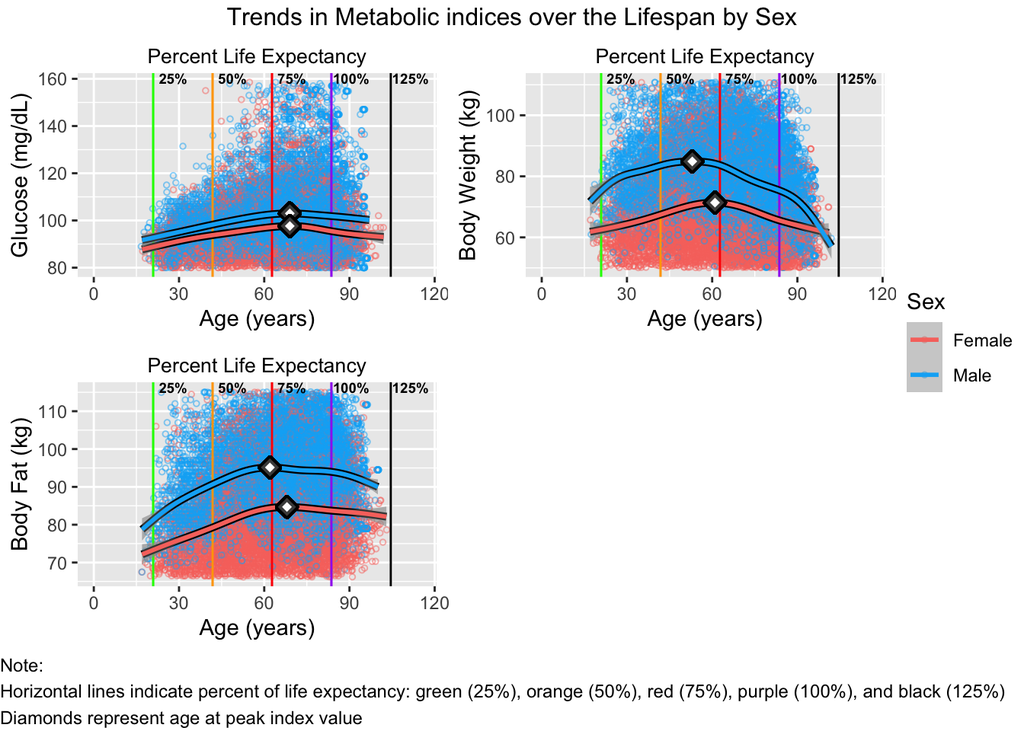

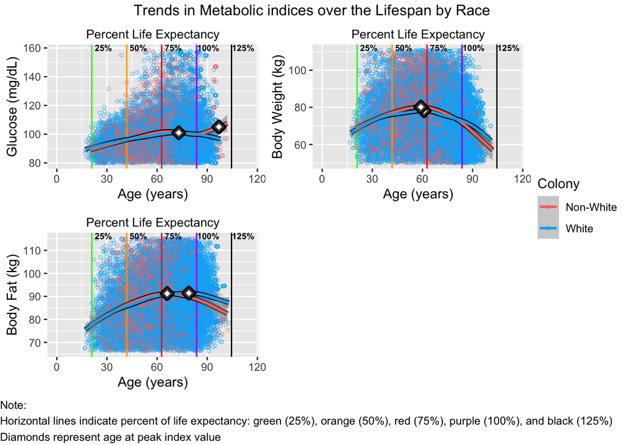

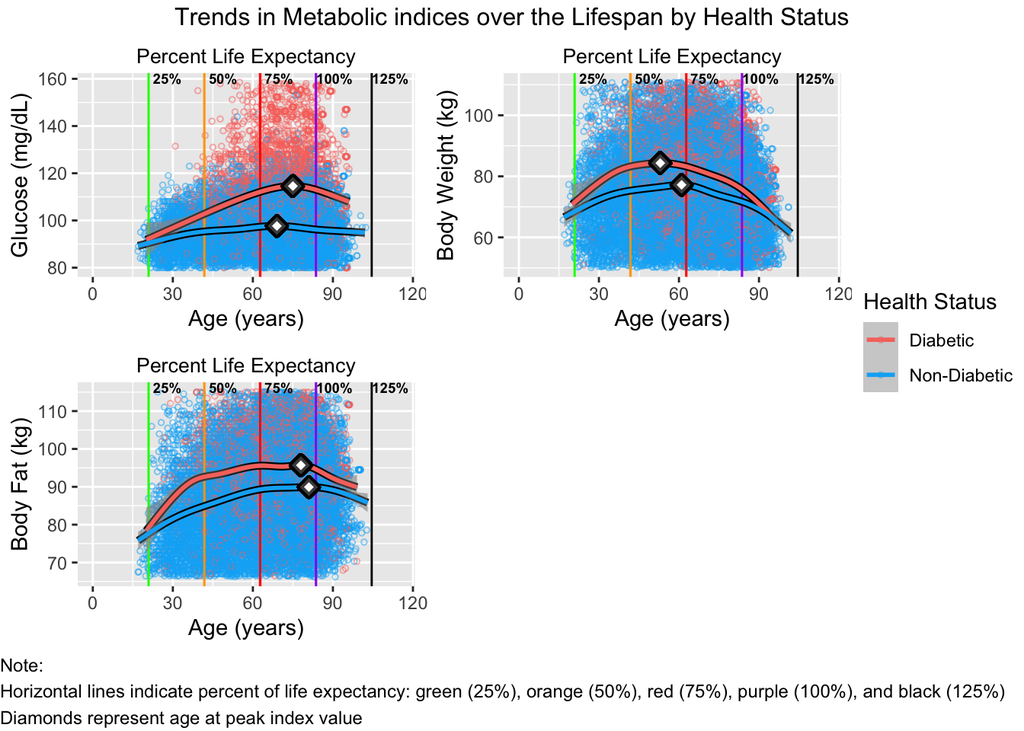

#### pre and post-peak change creation

#### change in metabolic indices pre and post-peak

- rate of percent change

Rate of Percent Change for Metabolic indices Pre- and Post-peak

| Metabolic Index | Age at Peak Value$^‡$ (% life expectancy) All | Age at Peak Value$^‡$ (% life expectancy) Female | Age at Peak Value$^‡$ (% life expectancy) Male | Pre-Peak$^§$$^¶$ All | Pre-Peak$^§$$^¶$ Female | Pre-Peak$^§$$^¶$ Male | Post-Peak$^§$$^¶$ All | Post-Peak$^§$$^¶$ Female | Post-Peak$^§$$^¶$ Male |
| --- | --- | --- | --- | --- | --- | --- | --- | --- | --- |
| gluc | 84.89 (76.52, 93.26) | 81.02 (72.8, 89.24) | 83.29 (73.64, 91.74) | 0.98 (0.83, 1.13)* | 0.88 (0.70, 1.05)* | 0.96 (0.76, 1.17)* | -0.43 (-0.73, -0.13)† | -0.61 (-1.02, -0.21)† | -0.40 (-0.62, -0.18)† |
| bw | 72.93 (64.56, 77.71) | 71.63 (63.41, 78.68) | 63.98 (53.11, 72.43) | 1.63 (1.30, 1.97)* | 1.50 (1.14, 1.87)* | 1.76 (1.23, 2.29)* | -2.31 (-2.73, -1.90)† | -1.48 (-1.96, -1.01) | -2.77 (-3.18, -2.36)† |
| fat | 95.65 (76.52, 102.82) | 79.85 (70.46, 90.42) | 74.84 (66.39, 82.09) | 1.31 (1.15, 1.48)* | 1.40 (1.17, 1.63)* | 1.77 (1.51, 2.02)* | -1.05 (-1.56, -0.53)† | -0.37 (-0.75, 0.01)† | -0.59 (-0.82, -0.36)* |

* p value < 0.05  
† Insufficient sample size to conduct a statistical test of significance  
‡ Mean (range of ages at similar values) of age at peak index value  
<sup>§</sup> Mean (95% confidence interval) rate of percent change during phase per five percent change in life expectancy  
<sup>¶</sup> Pre-peak is defined as 25% life expectancy to age at peak value; post-peak phase is defined as peak to 125% life expectancy  
** Male and female estimates are based on sex specific life expectancy

#### kaplan meier survival curves

- comparing highest to lowest quartile
- three timepoints: 50, 75, and 100% life expectancy

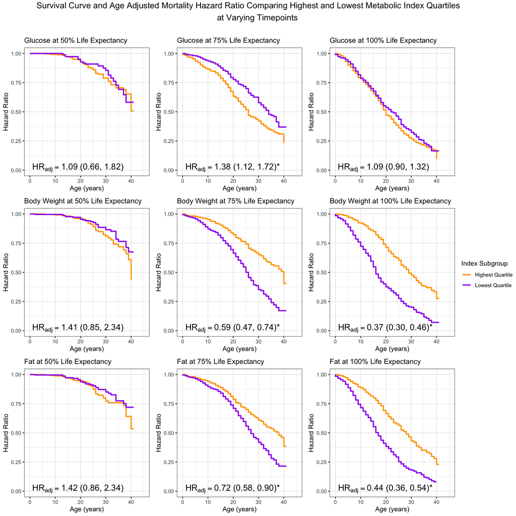

#### cox proportional mortality hazard ratios

- sex specific
- covariate adjustment
  - sex, age
  - additional adjustment for body fat

Mortality Hazard Ratios of Highest and Lowest Glucose Quartiles at Varying Timepoints Stratified by Sex

| Timepoint | All Model 1 | All Model 2 | Female Model 1 | Female Model 2 | Male Model 1 | Male Model 2 |
| --- | --- | --- | --- | --- | --- | --- |
| 50 | 1.09 (0.65, 1.81) | 0.90 (0.53, 1.53) | 1.87 (0.74, 4.69) | 1.75 (0.69, 4.44) | 0.78 (0.42, 1.46) | 0.52 (0.26, 1.04) |
| 75 | 1.38 (1.11, 1.71)* | 1.63 (1.29, 2.05)* | 1.57 (1.08, 2.28)* | 1.87 (1.25, 2.78)* | 1.28 (0.98, 1.67) | 1.50 (1.12, 2.00)* |
| 100 | 1.08 (0.89, 1.31) | 1.55 (1.26, 1.91)* | 1.23 (0.87, 1.73) | 1.80 (1.23, 2.63)* | 1.01 (0.80, 1.28) | 1.46 (1.14, 1.86)* |

* p-value < 0.05  
† Hazard ratios (95% confidence intervals) are adjusted for: Model 1) age and sex; Model 2) additionally adjusted for body composition

Mortality Hazard Ratios of Highest and Lowest Body Weight and Composition Quartiles at Varying Timepoints Stratified by Sex

| Metabolic Index | Timepoint$^†$ | All | Female | Male |
| --- | --- | --- | --- | --- |
| Body Weight | 50 | 1.38 (0.83, 2.29) | 1.58 (0.73, 3.40) | 1.26 (0.63, 2.51) |
|  | 75 | 0.59 (0.48, 0.74)* | 0.63 (0.43, 0.91)* | 0.57 (0.43, 0.75)* |
|  | 100 | 0.37 (0.30, 0.45)* | 0.39 (0.27, 0.56)* | 0.36 (0.28, 0.46)* |
| Body Composition | 50 | 1.40 (0.85, 2.31) | 1.23 (0.59, 2.57) | 1.70 (0.84, 3.47) |
|  | 75 | 0.72 (0.58, 0.89)* | 0.74 (0.51, 1.08) | 0.72 (0.55, 0.94)* |
|  | 100 | 0.43 (0.35, 0.52)* | 0.55 (0.39, 0.77)* | 0.38 (0.30, 0.48)* |

* p-value < 0.05  
† Hazard ratios are adjusted for age and sex  
‡ Timepoint is percent of mean life expectancy

## Author Questions

#### determine assessments over lifespan

Assessments of Metabolic indices Over the Lifespan

| Timepoint$^‡$ | Population New Participants | Population Alive | Population Dead | Glucose Measured | Glucose Imputed | Glucose Missing | Body Weight Measured | Body Weight Imputed | Body Weight Missing | Body Composition Measured | Body Composition Imputed | Body Composition Missing |
| --- | --- | --- | --- | --- | --- | --- | --- | --- | --- | --- | --- | --- |
| 25 | 417 | 417 | 117 | 417 | 0 | 0 | 414 | 0 | 3 | 395 | 0 | 22 |
| 50 | 871 | 1171 | 424 | 1141 | 30 | 0 | 1155 | 14 | 2 | 1142 | 17 | 12 |
| 75 | 1136 | 1883 | 824 | 1785 | 89 | 9 | 1832 | 43 | 8 | 1817 | 51 | 15 |
| 100 | 599 | 1658 | 1510 | 1408 | 234 | 16 | 1477 | 172 | 9 | 1451 | 187 | 20 |
| 125 | 0 | 148 | 148 | 33 | 114 | 1 | 59 | 88 | 1 | 48 | 96 | 4 |

* Imputation using last observed value carried forward  
† Timepoint is percent of mean life expectancy

#### trajectories by varying survival groups

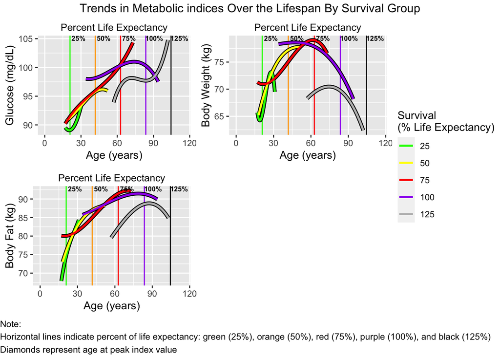